# Où vont nos boursières et boursiers Postdoc.Mobility ? L’Europe a le vent en poupe

13.07.2022

**Le FNS envoie chaque année des centaines de chercheuses et de chercheurs en début de carrière dans le monde entier pour participer à des séjours de recherche internationaux pluriannuels. Où vont-ils?**

Pour la plupart, ces personnes ont terminé leur doctorat ou leur formation médicale en Suisse. Elles effectuent ensuite des recherches postdoctorales à l’étranger avec l’instrument de financement [Postdoc.Mobility](http://www.snf.ch/en/funding/careers/postdoc-mobility/Pages/default.aspx) du FNS. Le montant moyen de ces bourses de deux ans est évalué à environ 107 000 francs suisses pour 2021. Ces séjours (environ 400 par an) permettent aux bénéficiaires d’approfondir leurs connaissances, d’accroître leur indépendance scientifique et d’améliorer leur profil, avant de revenir faire carrière en Suisse. Ils jouent également un rôle important dans les relations entre la Suisse et la communauté internationale de la recherche.

### Pays les plus fréquentés

Les destinations les plus fréquentées par les bénéficiaires d’une bourse Postdoc.Mobility, entre 2005 et 2021, sont présentées dans le graphique ci-dessous. Quatre des six premiers pays sont anglophones, les deux autres étant l’Allemagne et la France.

Pays d’accueil Postdoc.Mobility les plus fréquentés

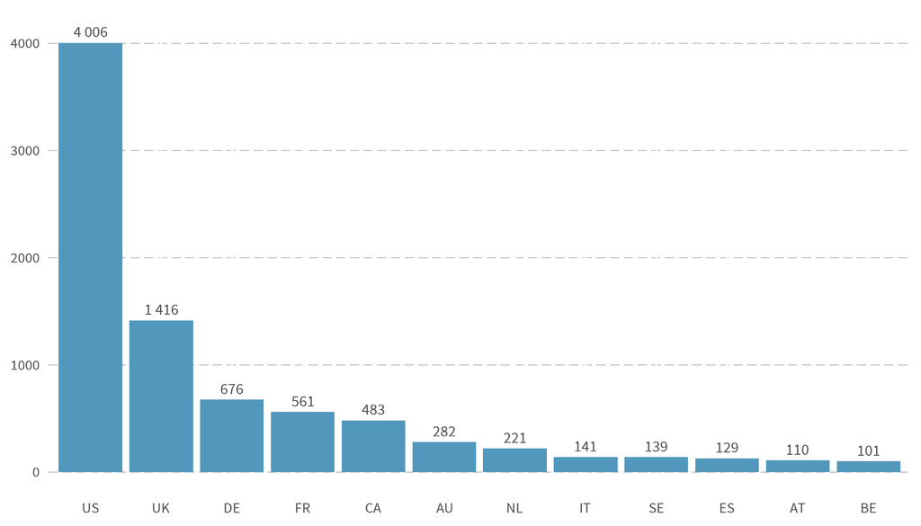

Nombre total de séjours dans les destinations des bourses Postdoc.Mobility entre 2005 et 2021.

### Tendances au fil des ans

Si les États-Unis restent de loin le pays le plus fréquenté, sa popularité est en baisse depuis 2013. Cette baisse peut être en partie attribuable à la situation politique, avec une politique d’immigration plus restrictive. Fait intéressant, le nombre de séjours Postdoc.Mobility au Royaume-Uni est resté plutôt constant et n’a pas connu une telle baisse jusqu’à présent, malgré l’arrivée du Brexit. Parallèlement, toute l’Europe continentale est devenue plus attrayante pour les bénéficiaires, ce que reflète un nombre croissant de séjours.

Bourses en Europe continentale, aux États-Unis et au Royaume-Uni

[interactive chart not shown]

Pourcentage annuel du total mondial des bourses Postdoc.Mobility en Europe continentale, aux États-Unis et au Royaume-Uni.

Une sélection de pays présentant les tendances les plus intéressantes est illustrée ci-dessous. La France était très prisée vers 2012-2013, suivie immédiatement d’une forte baisse des séjours, mais elle a attiré ces dernières années à nouveau plus de chercheuses et chercheurs en début de carrière. La diminution du nombre de bourses aux États-Unis n’a pas entraîné une augmentation dans d’autres pays anglophones, car nous constatons une légère tendance à la baisse au Canada et en Australie. En revanche, le pourcentage de bourses accordées vers l’Allemagne, les Pays-Bas et l’Autriche a généralement augmenté.

Les pays qui ne sont pas mis en évidence dans ces chiffres ne présentent pas de tendances pluriannuelles particulières dans le pourcentage de bénéficiaires Postdoc.Mobility.

Bourses dans d’autres pays de premier plan

[interactive chart not shown]

Pourcentage annuel du total mondial des bourses Postdoc.Mobility dans une sélection de pays. Les pays non représentés ici n’ont pas montré de tendances marquantes.

Le graphique ci-dessous montre le nombre de bourses par continent, réparti par domaine de recherche (SHS : sciences sociales et humaines, MINT : mathématiques, sciences naturelles et du génie, SV : sciences de la vie). L’Amérique du Nord et l’Océanie affichent un plus grand nombre de bourses axées sur les sciences de la vie, tandis que les sciences sociales et humaines sont les plus fréquentes sur les autres continents. Le nombre de bourses est particulièrement faible en Amérique latine et en Afrique. Ces chiffres regroupent le Mexique avec l’Amérique latine.

Bourses dans les différents continents et domaines de recherche

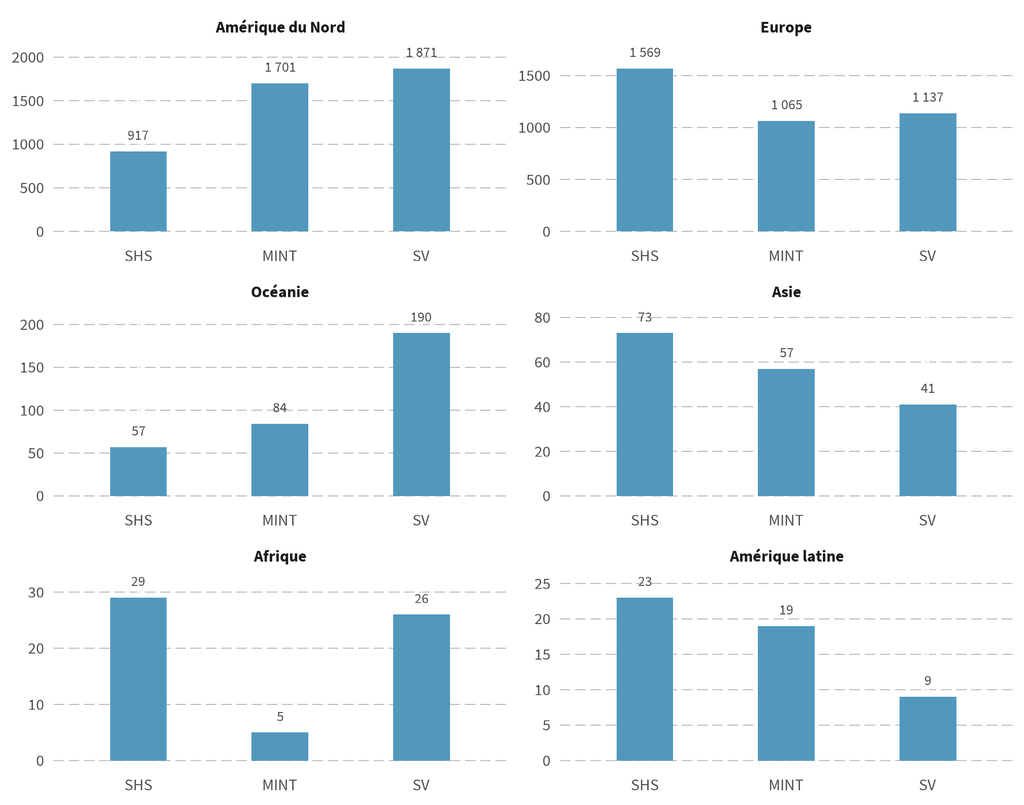

Nombre de bourses Postdoc.Mobility dans les différents domaines de recherche et continents. Le Mexique est inclus dans l’Amérique latine.

Le pourcentage de bourses vers les pays européens a augmenté ces dernières années, tandis que celles vers l’Océanie et l’Amérique du Nord sont en baisse depuis 2015. La baisse en Océanie, après 2020, peut être due aux mesures relatives à la pandémie avec des règles de voyage et d’immigration très strictes, en particulier en Australie et Nouvelle-Zélande. En comparaison, le nombre de bourses en Asie est resté relativement faible.

Bourses dans les différents domaines de recherche et les quatre continents les plus fréquentés au fil du temps

[interactive chart not shown]

Pourcentage annuel du total mondial des bourses Postdoc.Mobility dans les différents domaines de recherche et les quatre continents les plus fréquentés au fil du temps. Les continents restants ne sont pas affichés en raison du faible nombre de bourses. Veuillez noter que les deux graphiques de la rangée supérieure montrent des sections d’axe Y différentes de celles des deux graphiques de la rangée inférieure.

Les tableaux suivants montrent le montant moyen accordé par an aux bourses Postdoc.Mobility pour chaque continent, et le montant total accordé par domaine de recherche pour chaque continent, depuis 2005. Il est important de mentionner que le montant accordé aux bénéficiaires est principalement défini par le coût de la vie dans le pays de destination.

Montant moyen des financements accordés pour les bourses Postdoc.Mobility (en francs suisses) pour chaque continent de 2005 à 2021

| Continent | Moyenne des fonds accordés |
| --- | --- |
| Asie | 81 240 |
| Europe | 80 908 |
| Océanie | 80 027 |
| Amérique du Nord | 77 943 |
| Amérique latine | 74 445 |
| Africa | 72 261 |

Financement total accordé (en francs suisses) pour les bourses Postdoc.Mobility par domaine de recherche pour chaque continent de 2005 à 2021

| Continent | SHS | MINT | SV | Totale |
| --- | --- | --- | --- | --- |
| Africa | 2 292 260 | 417 188 | 1 626 228 | 4 335 676 |
| Amérique du Nord | 77 590 288 | 129 508 339 | 141 540 260 | 348 638 887 |
| Amérique latine | 1 890 886 | 1 255 248 | 650 585 | 3 796 719 |
| Asie | 6 838 991 | 4 041 537 | 2 930 357 | 13 810 885 |
| Europe | 140 648 041 | 79 320 089 | 84 407 284 | 304 375 414 |
| Océanie | 5 727 051 | 6 367 585 | 14 314 342 | 26 408 978 |
| Totale | 234 987 517 | 220 909 986 | 245 469 056 | 701 366 559 |

### Diminution depuis 2020

Les chiffres comprennent toutes les formes de la bourse Postdoc.Mobility, y compris les volets précédents Early et Advanced Postdoc.Mobility. La plupart des bénéficiaires effectuent la totalité de leur séjour dans un seul établissement, mais environ un sur six en fréquente plusieurs. Dans ce récit de données, chaque institution est comptée séparément et les subsides de retour en Suisse ne sont pas inclus. De plus, tous les chercheuses et chercheurs compris dans cette analyse avaient déjà terminé leur doctorat et étaient considérés comme des postdoctorant·es au moment de leur bourse. La baisse des octrois depuis 2020 s’explique d’une part par un budget réduit en 2020, et d’autre part par la fusion d’Early Postdoc.Mobility avec Postdoc.Mobility en 2021.

Bourses accordées et nombre total d’institutions internationales fréquentées chaque année de 2005 à 2021

[interactive chart not shown]

Nombre de boursières et boursiers Postdoc.Mobility et nombre d’institutions de recherche fréquentées au fil du temps.

De plus amples informations sont disponibles sur la page [Internationalité](https://data.snf.ch/key-figures/internationality) des Chiffres clés du FNS, où les doctorant·es de l’instrument Doc.Mobility sont également inclus dans les données sur les bourses.

### Suivi de nos bénéficiaires

Le FNS s’intéresse également à l’impact de ses instruments d’encouragement de carrières, dont Postdoc.Mobility fait partie. C’est pourquoi le projet [Career Tracker Cohorts (FNS-CTC)](https://careertrackercohorts.ch/) a été lancé en 2018. Cette initiative vise à mieux comprendre les parcours professionnels des candidat·es aux instruments de financement de carrières après le doctorat, ainsi que l’impact à moyen et long terme des instruments d’encouragement de carrières du FNS.

Les données, le texte et le code associés à ce récit de données sont disponibles sur [Github](https://github.com/snsf-data/datastory_fellowships_worldwide) et archivés sur [Zenodo](https://doi.org/10.46446/datastory.where-do-our-postdoc-mobility-grantees-go) DOI : 10.46446/datastory.where-do-our-postdoc-mobility-grantees-go